# The analytic model: hard topics, exact posterior

Albin Thörn Cleland

2026-10-14

## The question

P.Oxy. 5292 preserves twelve intact trimeters of Sophocles’ *Tereus* and seventeen damaged ones (vv. 13–29). Several restorers have filled the damaged verses: W. B. Henry, the Stoicheia fill-in model, and judge-steered Markov walks. Which topics does each restorer put into each lost verse, and does that differ from what Sophocles writes elsewhere?

## The model

Every lemma of the vocabulary belongs to exactly one of $K$ semantic clusters (word2vec on the lemmatised Greek corpus, Ward’s method, cut at $K = 40$, one rare-lemma cluster dropped). A **document** is $N$ consecutive topic-bearing lemmata of a stream, and its topic counts are

$$\mathbf n \mid \theta \sim
\mathrm{Multinomial}(N, \theta), \qquad \theta \sim
\mathrm{Dirichlet}(\alpha \mathbf 1).$$

The Dirichlet is conjugate to the multinomial, so the posterior is exact,

$$\theta \mid \mathbf n \sim
\mathrm{Dirichlet}(\alpha \mathbf 1 + \mathbf n),$$

and needs no sampler beyond `rgamma`. A **cell** (one lacuna, one restorer) is the equal mixture of its documents’ posteriors: its spread is the spread between restorations plus the Dirichlet uncertainty of each. Sophocles’ extant trimeters are treated the same way, and a cell is compared with them by $P(\theta_k^{\text{cell}} > \theta_k^{\text{Soph}})$ over paired draws and by the lift of the posterior means.

## Data

The dataset Urdatorn/bsda-miniproject-2026: one bag of content lemmata per restored verse, the vocabulary with its cluster labels, and the corpus of the three tragedians.

```r
vocab  <- fromJSON(file.path(params$data, "vocab.json"))              # index, lemma, tragic_count, cluster_K40 (NA = no topic)
corpus <- read_parquet(file.path(params$data, "corpus.parquet"))
imp    <- read_parquet(file.path(params$data, "imputations.parquet"))
stream <- function(tab) rep(unlist(tab$lemma_idx), unlist(tab$count))  # bags -> lemma indices (0-based), counts expanded
topics <- function(s) { t <- vocab$cluster_K40[s + 1]; t[!is.na(t)] }  # lemma indices -> topic labels, dropping topicless lemmata
tragic <- filter(corpus, source %in% c("sophocles", "aeschylus", "euripides"))
names_ <- names(sort(table(topics(stream(tragic))), decreasing = TRUE)); K <- length(names_)
cat(K, "topics;", nrow(vocab), "lemmata,", sum(!is.na(vocab$cluster_K40)), "with a topic;", nrow(imp), "restored verses\n")
```

```
## 39 topics; 3504 lemmata, 3417 with a topic; 631974 restored verses
```

## Documents and the exact posterior

```r
n <- params$n; alpha <- params$alpha; draws <- params$draws; max_docs <- params$max_docs
docs <- function(s, limit, shuffle = FALSE) {                        # cut a topic stream into documents of exactly n labels
  x <- topics(s); if (shuffle) x <- sample(x); m <- length(x) %/% n; if (m == 0) return(list())
  d <- split(x[seq_len(m * n)], rep(seq_len(m), each = n)); if (m > limit) d <- d[sort(sample(m, limit))]; d }
rdirichlet <- function(S, par) { g <- matrix(rgamma(S * length(par), par), S, byrow = TRUE); g / rowSums(g) }
posterior <- function(d) do.call(rbind, lapply(d, function(x) rdirichlet(draws, alpha + tabulate(match(x, names_), K))))
cell <- function(d, base = NULL) {
  if (!length(d)) return(NULL); P <- posterior(d); s <- list(n_docs = length(d), mean = colMeans(P), P = P)
  if (!is.null(base)) { B <- base[sample(nrow(base), nrow(P), replace = TRUE), ]; s$p_above <- colMeans(P > B); s$lift <- colMeans(P) / colMeans(base) }
  s }
untilted <- function(tab) filter(tab, !coalesce(style_tilted, FALSE))  # the tilt flag is null for Stoicheia and the candidates
```

```r
soph  <- cell(docs(stream(filter(corpus, source == "sophocles")), 4 * max_docs))
cells <- list(walk  = cell(docs(stream(untilted(filter(imp, restorer == "walk"))), 2 * max_docs), soph$P),
              henry = cell(list(topics(stream(arrange(filter(corpus, source %in% c("intact", "henry")), line)))), soph$P))
for (v in 13:29) for (r in c("stoicheia", "candidates", "walk"))
  cells[[paste(v, r)]] <- cell(docs(stream(untilted(filter(imp, verse == v, restorer == r))), max_docs, shuffle = TRUE), soph$P)
rows <- bind_rows(lapply(names(cells), function(cl) { s <- cells[[cl]]; if (is.null(s)) return(NULL)
  tibble(cell = cl, topic = names_, n_docs = s$n_docs, mean = s$mean, p_above_sophocles = s$p_above, lift = s$lift) }))
write.csv(rows, file.path(params$out, "posterior.csv"), row.names = FALSE)
```

## Sophocles’ baseline

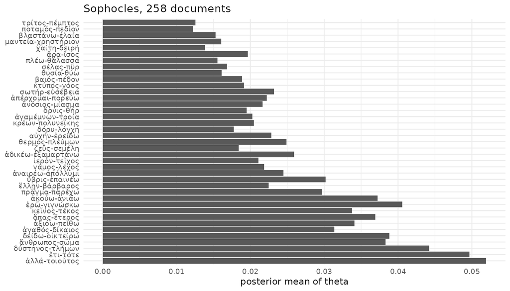

```r
tibble(topic = factor(names_, names_), mean = soph$mean) |>
  ggplot(aes(topic, mean)) + geom_col() + coord_flip() + labs(x = NULL, y = "posterior mean of theta", title = sprintf("Sophocles, %d documents", soph$n_docs)) + theme_minimal(9)
```

## Topics raised above Sophocles

Topics with $P(\theta_k^{\text{cell}} > \theta_k^{\text{Soph}}) \ge 0.9$, with the lift of the posterior mean and the mean itself.

```r
raised <- rows |> filter(p_above_sophocles >= 0.9) |> arrange(cell, desc(lift)) |> group_by(cell, n_docs) |>
  summarise(raised = paste0(topic, " (", sprintf("%.1f", lift), "×, ", sprintf("%.2f", mean), ")", collapse = ", "), .groups = "drop")
knitr::kable(raised, col.names = c("cell", "documents", "topics raised"))
```

| cell | documents | topics raised |
| --- | --- | --- |
| 13 candidates | 32 | δύστηνος-τλήμων (3.2×, 0.14) |
| 13 stoicheia | 45 | ἀλλά-τοιοῦτος (2.8×, 0.14) |
| 14 stoicheia | 44 | ἄνθρωπος-σῶμα (4.0×, 0.15) |
| 14 walk | 403 | πλέω-θάλασσα (4.5×, 0.07) |
| 15 candidates | 31 | δύστηνος-τλήμων (2.5×, 0.11) |
| 16 candidates | 35 | ἄνθρωπος-σῶμα (3.5×, 0.14) |
| 16 stoicheia | 52 | κεῖνος-τέκος (3.5×, 0.12), ἀκούω-ἀνιάω (2.8×, 0.11) |
| 17 candidates | 27 | ἄνθρωπος-σῶμα (3.3×, 0.13), δύστηνος-τλήμων (2.8×, 0.12) |
| 17 stoicheia | 36 | ἀγαθός-δίκαιος (3.1×, 0.10) |
| 18 candidates | 31 | ἀγαθός-δίκαιος (6.5×, 0.20), δύστηνος-τλήμων (2.5×, 0.11) |
| 18 stoicheia | 48 | ἀδικέω-ἐξαμαρτάνω (5.6×, 0.15), ἀγαθός-δίκαιος (2.7×, 0.09) |
| 18 walk | 399 | ἀγαθός-δίκαιος (3.0×, 0.09) |
| 19 candidates | 42 | ἀξιόω-πείθω (6.1×, 0.21), τρίτος-πέμπτος (4.2×, 0.05) |
| 20 candidates | 36 | δύστηνος-τλήμων (3.2×, 0.14) |
| 20 stoicheia | 37 | ἀδικέω-ἐξαμαρτάνω (3.2×, 0.08) |
| 21 candidates | 15 | ἀκούω-ἀνιάω (3.0×, 0.11), δύστηνος-τλήμων (2.9×, 0.13) |
| 22 candidates | 27 | δύστηνος-τλήμων (5.4×, 0.24) |
| 22 stoicheia | 46 | ἀξιόω-πείθω (2.8×, 0.10) |
| 23 candidates | 30 | ἀξιόω-πείθω (4.9×, 0.17), δύστηνος-τλήμων (2.8×, 0.12) |
| 24 candidates | 26 | δύστηνος-τλήμων (4.3×, 0.19), ἀγαθός-δίκαιος (3.7×, 0.12) |
| 26 candidates | 45 | ἅπας-ἕτερος (2.7×, 0.10) |
| 26 stoicheia | 60 | ἀνόσιος-μίασμα (3.4×, 0.07), ἀξιόω-πείθω (3.0×, 0.10) |
| 27 candidates | 37 | δύστηνος-τλήμων (2.7×, 0.12) |
| 28 candidates | 23 | ὄρνις-θήρ (4.1×, 0.08) |
| henry | 1 | ἄνθρωπος-σῶμα (2.7×, 0.10) |

## Lift of every topic in every cell

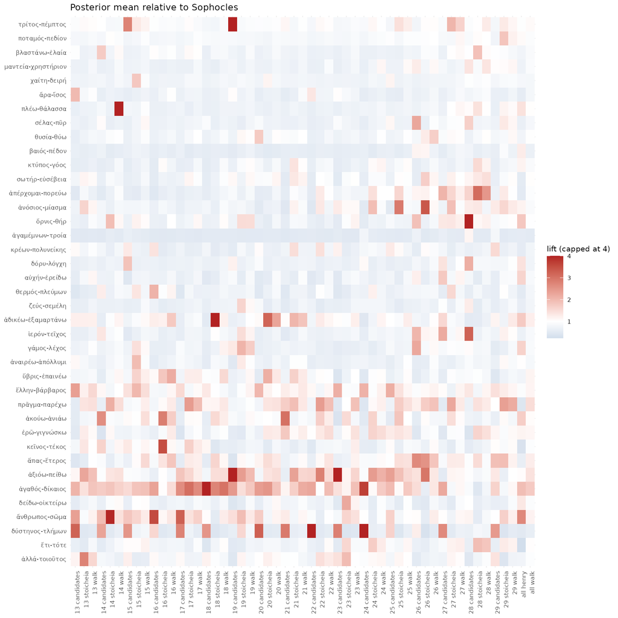

```r
rows |> separate(cell, c("verse", "restorer"), sep = " ", fill = "right") |>
  mutate(restorer = coalesce(restorer, verse), verse = ifelse(verse %in% c("walk", "henry"), "all", verse),
         topic = factor(topic, names_), label = paste(verse, restorer)) |>
  ggplot(aes(label, topic, fill = pmin(lift, 4))) + geom_tile() +
  scale_fill_gradient2(midpoint = 1, low = "steelblue", high = "firebrick", name = "lift (capped at 4)") +
  labs(x = NULL, y = NULL, title = "Posterior mean relative to Sophocles") + theme_minimal(8) + theme(axis.text.x = element_text(angle = 90, hjust = 1))
```

## Where the walk and Henry stand

```r
rows |> filter(cell %in% c("walk", "henry")) |> arrange(cell, desc(lift)) |> group_by(cell) |> slice_head(n = 5) |>
  select(cell, topic, mean, p_above_sophocles, lift) |> knitr::kable(digits = 2)
```

| cell | topic | mean | p_above_sophocles | lift |
| --- | --- | --- | --- | --- |
| henry | ἄνθρωπος-σῶμα | 0.10 | 0.92 | 2.70 |
| henry | ἀγαθός-δίκαιος | 0.06 | 0.86 | 1.93 |
| henry | ὄρνις-θήρ | 0.03 | 0.77 | 1.79 |
| henry | ἀδικέω-ἐξαμαρτάνω | 0.05 | 0.71 | 1.74 |
| henry | ἀκούω-ἀνιάω | 0.06 | 0.85 | 1.70 |
| walk | ἀγαθός-δίκαιος | 0.05 | 0.70 | 1.74 |
| walk | πρᾶγμα-παρέχω | 0.04 | 0.63 | 1.48 |
| walk | ἀξιόω-πείθω | 0.05 | 0.62 | 1.40 |
| walk | ἅπας-ἕτερος | 0.05 | 0.57 | 1.25 |
| walk | ἀδικέω-ἐξαμαρτάνω | 0.03 | 0.56 | 1.23 |